# Naive Bayes

Pongsun B.

2026-02-04

### 1. What is the naive Bayes algorithm?

Imagine that 0.2% of the population have unicorn disease (symptoms include obsession with glitter and compulsive rainbow drawing). The test for unicorn disease has a true positive rate of 90% (if you have the disease, the test will detect it 90% of the time). When tested, 5% of the whole population get a positive result from the test. Based on this information, if you get a positive result from the test, what is the probability you have unicorn disease?

Many people’s instinct is to say 90%, but this doesn’t account for how prevalent the disease is and the proportion of tests that are positive (which also includes false positives). So how do we estimate the probability of having the disease, given a positive test result? Well, we use **Bayes’ rule**.

- *p*(*k*|*x*) is the probability of having the disease (*k*) given a positive test result (*x*). This is called the *posterior probability*.
- *p*(*x*|*k*) is the probability of getting a positive test result if you *do* have the disease. This is called the *likelihood*.
- *p*(*k*) is the probability of having the disease regardless of any test. This is the proportion of people in the population with the disease and is called the *prior probability*.
- *p*(*x*) is the probability of getting a positive test result and includes the true positives and false positives. This is called the *evidence*.

So our likelihood (the probability of getting a positive test result if we do have unicorn disease) is 90%, or 0.9 expressed as a decimal. Our prior probability (the proportion of people with unicorn disease) is 0.2%, or 0.002 as a decimal. Finally, our evidence (the probability of getting a positive test result) is 5%, or 0.05 as a decimal. You can see all these values illustrated in **Figure 1**.

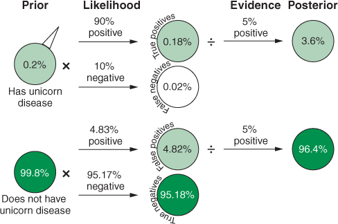

**Figure 1:** Using Bayes’ rule to calculate the posterior probability of having unicorn disease, given a positive test result. The priors are the proportion of people with or without the disease. The likelihoods are the probabilities of getting positive or negative test results for each disease status. The evidence is the probability of getting a positive test result (true positives plus the false positives).

Phew! After taking into account the prevalence of the disease and the proportion of tests that are positive (including false positives), a positive test means we have only a 3.6% chance of actually having the disease—much better than 90%! This is the power of Bayes’ rule: it allows you to incorporate prior information to get a more accurate estimation of *conditional probabilities* (the probability of something, given the data).

#### 1.1 Using naive Bayes for classification

Let’s take another, more machine learning–focused, example. Imagine that you have a database of tweets from the social media platform Twitter, and you want to build a model that automatically classifies each tweet into a topic. The topics are

- Politics
- Sports
- Movies
- Other

You create four categorical predictor variables:

- Whether the word opinion is present
- Whether the word score is present
- Whether the word game is present
- Whether the word cinema is present

Note that I’m keeping things simple for this example. If we were really trying to build a model to predict tweet topics, we would need to include many more words than this!

For each of our four topics, we can express the probability of a case belonging to that topic as

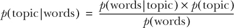

Now that we have more than one predictor variable, p(words|topic) is the likelihood of a tweet having that exact combination of words present, given the tweet is in that topic. We estimate this by finding the likelihood of having this combination of values of each predictor variable individually, given that the tweet belongs to that topic, and multiply them together.

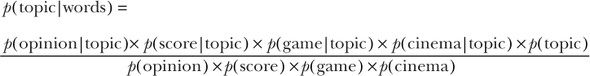

For example, if a tweet contains the words opinion, score, and game, but not cinema, then the likelihood would be as follows for any particular topic:

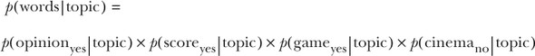

Now, the likelihood of a tweet containing a certain word if it’s in a particular topic is simply the proportion of tweets from that topic that contain that word. Multiplying the likelihoods together from each predictor variable gives us the likelihood of observing this *combination* of predictor variable values (this combination of words), given a particular class.

This is what makes naive Bayes “naive.” By estimating the likelihood for each predictor variable individually and then multiplying them, we are making the very strong assumption that the predictor variables are independent. In other words, we are assuming that the value of one variable has no relationship to the value of another one. In the majority of cases, this assumption is not true. For example, if a tweet contains the word *score*, it may be more likely to also include the word *game*.

In spite of this naive assumption being wrong quite often, naive Bayes tends to perform well even in the presence of non-independent predictors. Having said this, strongly dependent predictor variables will impact performance. So the likelihood and prior probabilities are fairly simple to compute and are the parameters learned by the algorithm; but what about the evidence (*p*(words))? In practice, because the values of the predictor variables are usually reasonably unique to each case in the data, calculating the evidence (the probability of observing that combination of values) is very difficult. As the evidence is really just a normalizing constant that makes all the posterior probabilities sum to 1, we can discard it and simply multiply the likelihood and prior probability:

$$posterior ∝ likelihood × prior$$

Note that instead of an `=` sign, I use $∝$ to mean “proportional to,” because without the evidence to normalize the equation, the posterior is no longer equal to the likelihood times the prior. This is okay, though, because proportionality is good enough to find the most likely class. Now, for each tweet, we calculate the relative posterior probability for each of the topics:

$$p(politics|words) ∝ p(words|politics) ×
p(politics)$$
$$p(sports|words) ∝
p(words|sports) × p(sports)$$
$$p(movies|words) ∝ p(words|movies) ×
p(movies)$$
$$p(other|words) ∝
p(words|other) × p(other)$$

Then we assign the tweet to the topic with the highest relative posterior probability.

#### 1.2 Calculating the likelihood for categorical and continuous predictors

When we have a categorical predictor (such as whether a word is present or not), naive Bayes uses that proportion of training cases in that particular class, with that value of the predictor. When we have a continuous variable, naive Bayes (typically) assumes that the data within each group is normally distributed. The probability density of each case based on this fitted normal distribution is then used to estimate the likelihood of observing this value of the predictor in that class. In this way, cases near the mean of the normal distribution for a particular class will have high probability density for that class, and cases far away from the mean will have a low probability density.

When your data has a mixture of categorical and continuous predictors, because naive Bayes assumes independence between data values, it simply uses the appropriate method for estimating the likelihood, depending on whether each predictor is categorical or continuous.

### 2. Building your first naive Bayes model

Let’s build and evaluate the performance of a naive Bayes model to predict political party affiliation. Imagine that you’re a political scientist. You’re looking for common voting patterns in the mid-1980s that would predict whether a US congressperson was a Democrat or Republican. You have the voting record of each member of the House of Representatives in 1984, and you identify 16 key votes that you believe most strongly split the two political parties. Your job is to train a naive Bayes model to predict whether a congressperson was a Democrat or a Republican, based on how they voted throughout the year.

#### 2.1 Loading and exploring the `HouseVotes84` dataset

Note that ordinarily I would manually give names to unnamed columns to make it clearer what I’m working with. In this example, the variable names are the names of votes and are a little cumbersome, so we’ll stick with V1, V2, and so on. If you want to see what issue each vote was for, run `?mlbench::House-Votes84`.

By default, the naive Bayes implementation that `mlr` uses is to keep cases and drop variables. This usually works fine if the ratio of missing to complete values for the majority of cases is quite small. However, if you have a small number of variables and a large proportion of missing values, you may wish to omit the cases instead (and, more broadly, consider whether your dataset is sufficient for training).

#### 2.3 Training the model

```r
politician <- tibble(V1 = "n", V2 = "n", V3 = "y", V4 = "n", V5 = "n", V6 = "y",
    V7 = "y", V8 = "y", V9 = "y", V10 = "y", V11 = "n", V12 = "y", V13 = "n", V14 = "n",
    V15 = "y", V16 = "n")
```

### 3. Strengths and weaknesses of naive Bayes

While it often isn’t easy to tell which algorithms will perform well for a given task, here are some strengths and weaknesses that will help you decide whether naive Bayes will perform well for your task.

The strengths of naive Bayes are as follows:

- It can handle both continuous and categorical predictor variables.
- It’s computationally inexpensive to train.
- It commonly performs well on topic classification problems where we want to classify documents based on the words they contain.
- It has no hyperparameters to tune.
- It is probabilistic and outputs the probabilities of new data belonging to each class.
- It can handle cases with missing data.

The weaknesses of naive Bayes are these:

- It assumes that continuous predictor variables are normally distributed (typically), and performance will suffer if they’re not.
- It assumes that predictor variables are independent of each other, which usually isn’t true. Performance will suffer if this assumption is severely violated.

### Exercise

#### Exercise 1

Use the `map_dbl()` function to count the number of `y` values in each column of `votesTib`.

#### Exercise 2

Wrap your naive Bayes model inside the `getLearnerModel()` function. Can you identify the prior probabilities and the likelihoods for each vote?

### Solution

```r
# Exercise 1



# Exercise 2



# Conclusion:
```

End-of-File  
2026-02-04